# Scenario analysis for the transmission and hospitalization of COVID-19 in the ACC Hospitals secondary service area

April 13, 2020

## Introduction

This document provides a very rough estimate of the COVID-19 outbreak in the Athens-Clarke county secondary service area.

To better understand the potential range of epidemic outcomes in the area, we used a model developed by the Center for the Ecology of Infectious Diseases at the University of Georgia based on data from Hubei Province, China calibrated to regionally specific conditions in Georgia. That Georgia-specific model was updated based on when the early cases in the ACC area began occurring.

More details about this model and its development can be found here:  
http://2019-coronavirus-tracker.com/stochastic-model.html

Calibration for Georgia can be found here:  
http://2019-coronavirus-tracker.com/stochastic-GA.html

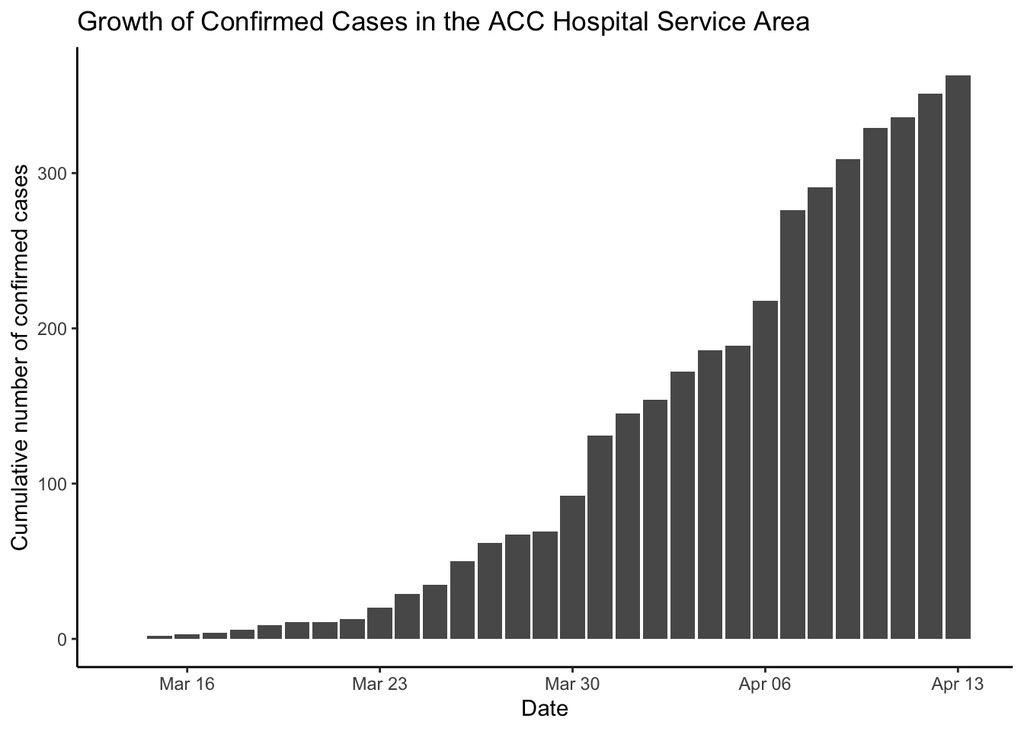

## The Models

Three basic models will be presented here. Each has been calibrated to fit the population size, date of the first confirmed case, and likely number of exposed (but not infectious) and infectious persons in the community when that first case was reported. A poor social distancing model will be included as the absolute worst-case scenario, with the basic assumption that the social distancing intervention put into place by Athens-Clarke and Oconnee counties has little to no effect on the spread of the virus (only case isolation after discovering cases). The other two models are calibrated to reduce transmission by 25% (average) and 50% (excellent). 50% is the estimated effect of very effective social distancing (and essentially lockdown) as was seen in some other settings.

The models are limited to showing results over the next three weeks.

### The Poor Social Distancing Model

The following plot predicts the natural epidemic if allowed to spread with no measures put into place.

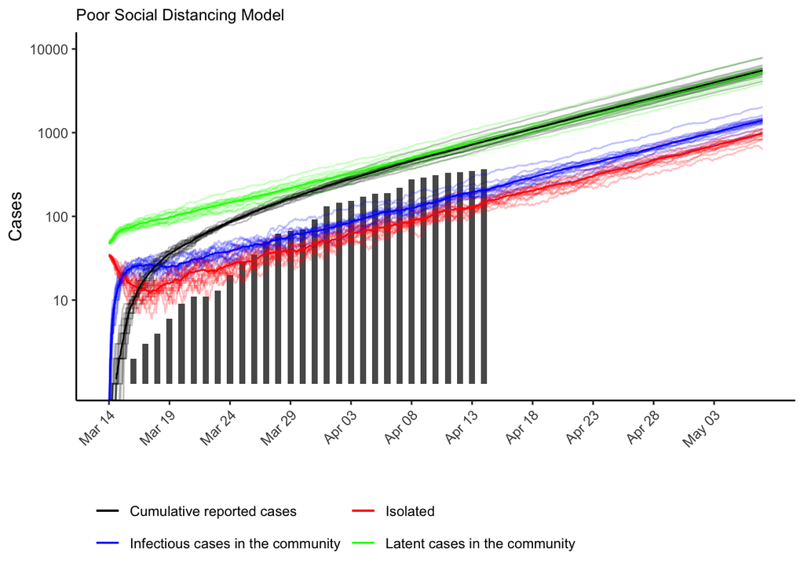

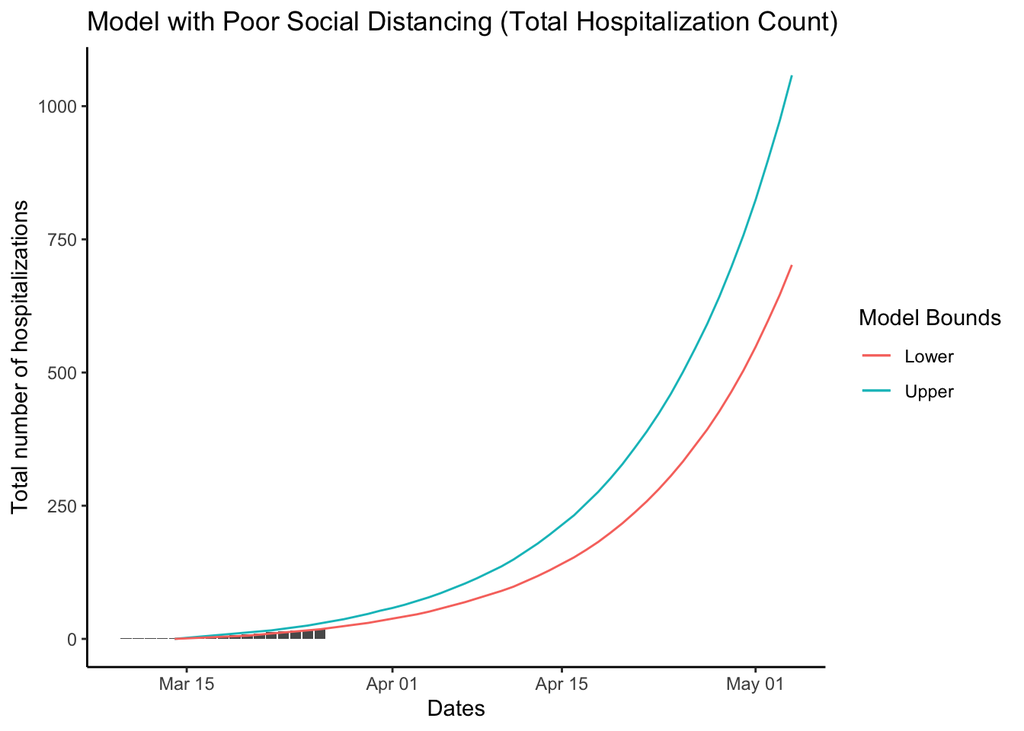

The current hospitalization count will also continue to rise, though not as fast as earlier patients are discharged.

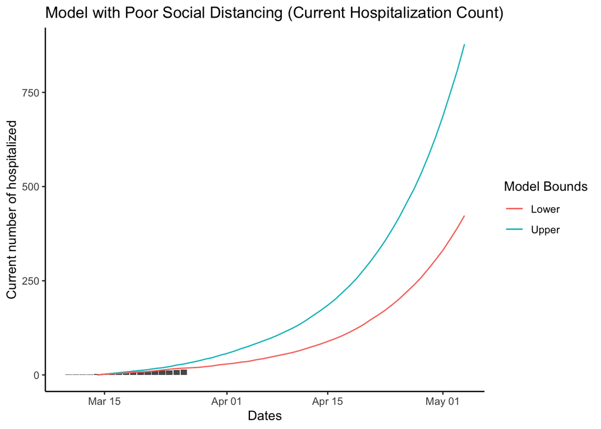

### The Average Social Distancing Effect Model

The following plot predicts transmission with an average social distancing effect.

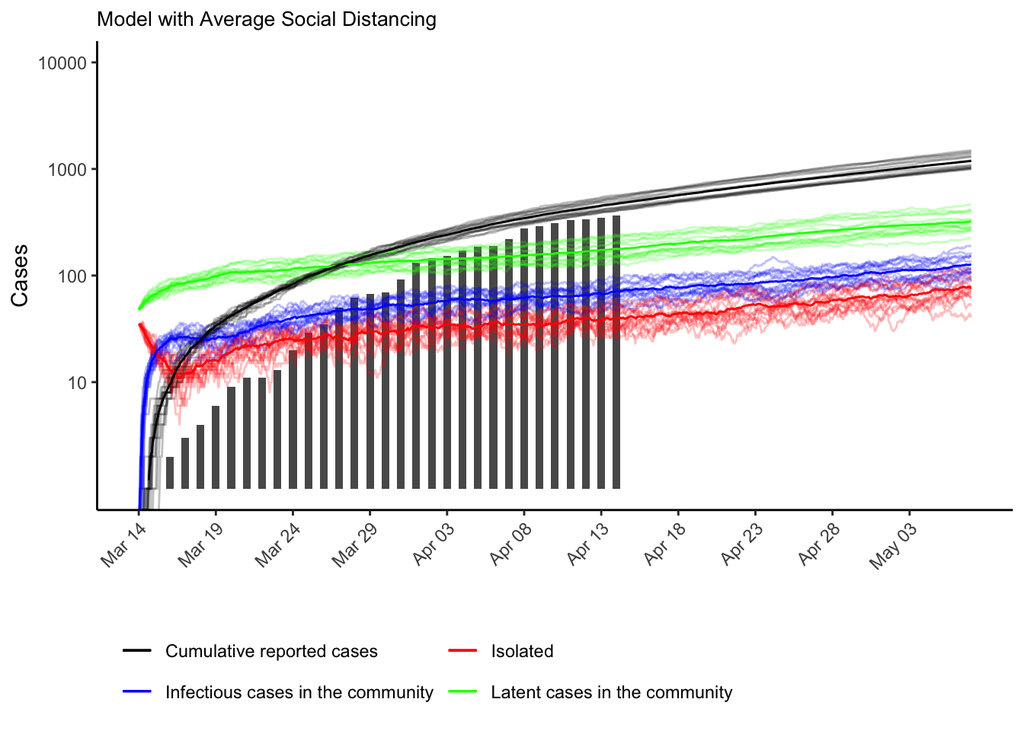

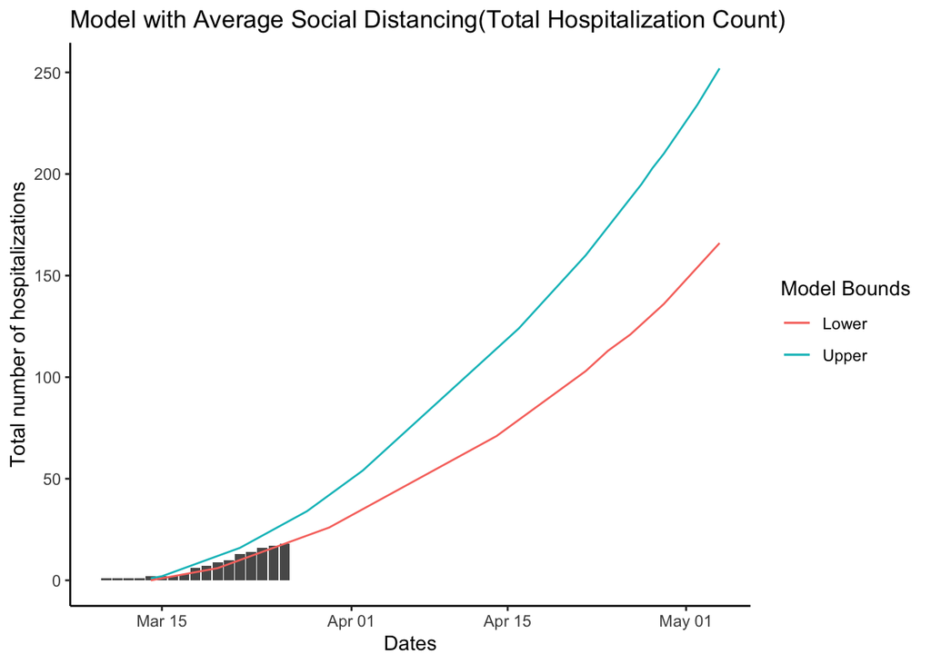

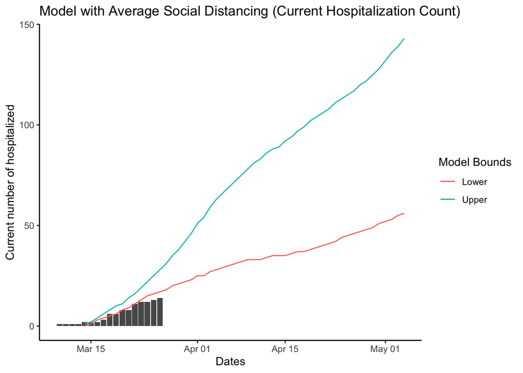

### The Excellent Social Distancing Effect Model

The following plot predicts transmission with an excellent social distancing effect.

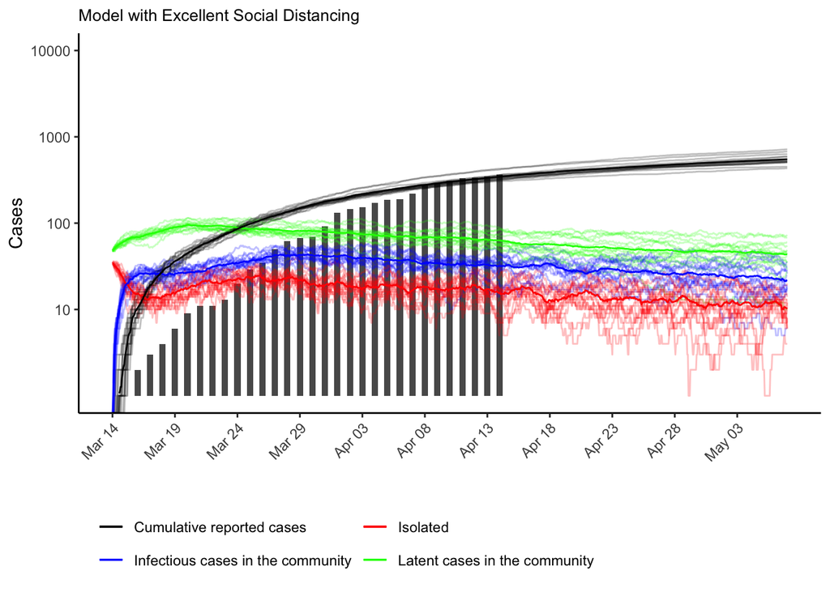

The number of new patients slows and total hospitalizations reaches around 70 by mid-April.

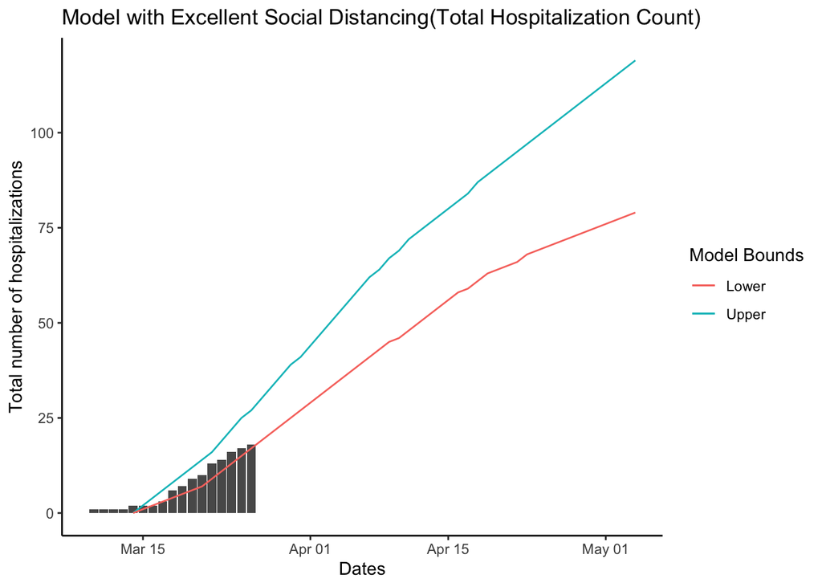

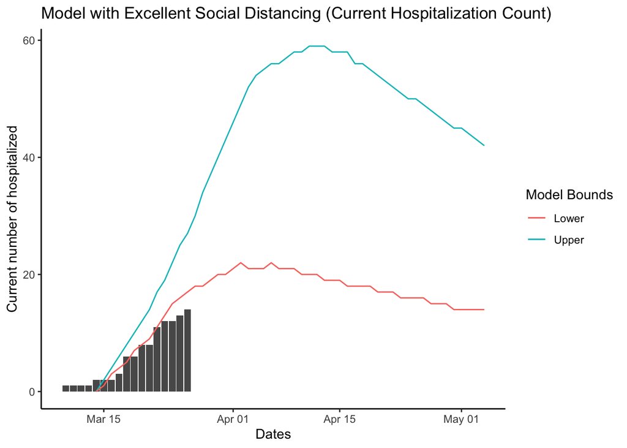